# Notebook

```python
import datetime
import dateutil.parser
import json
import matplotlib
import matplotlib.pyplot as plt
import numpy as np
import os
import pandas as pd
import requests
from scipy.misc import imread
from StringIO import StringIO
```

```python
%matplotlib inline
plt.rcParams['figure.figsize'] = (20, 10)
```

```python
#get the data about the base stations from the google spreadsheet
baseDataCSVaddress = "https://docs.google.com/spreadsheets/d/167pxh_NRq5e9sQV9Zb8Z-Q-kdN7Zy9FCzCp47eVXTuE/pub?gid=1446311565&single=true&output=csv"
r = requests.get(baseDataCSVaddress)
data = r.content
baseData = pd.read_csv(StringIO(data))

#only keep the columns we care about
baseData = baseData.ix[:,0:5]
baseData = baseData[baseData.agentId > 0] #not really sure how this works, maybe failure is falsy?
baseData.head(3)
```

|  | agentId | agentName | location | x | y |
| --- | --- | --- | --- | --- | --- |
| 0 | 00000000e5bd0ae9 | Ace | Citizen | 2953.206017 | 14427.458860 |
| 1 | 000000006c1a3b5a | Alfa | Between citizen and library | 3323.405966 | 9086.502512 |
| 2 | 0000000020294bbd | Beer | Sample Library | 3313.076869 | 2665.631392 |

```python
# read the entire file into a python array
thisManyRowsOfData = 200000
d = []
with open("200916_2_3.json", 'rb') as f:
    for i in range(thisManyRowsOfData):
        d.append(f.readline())
```

The data comes in as some kind of skanky hybrid of json and, er, something else. This section is ripped from SO and fixes it

```python
# remove the trailing "\n" from each line
data = map(lambda x: x.rstrip(), d)

# each element of 'data' is an individual JSON object.
# i want to convert it into an *array* of JSON objects
# which, in and of itself, is one large JSON object
# basically... add square brackets to the beginning
# and end, and have all the individual business JSON objects
# separated by a comma
data_json_str = "[" + ','.join(data) + "]"

# now, load it into pandas
df = pd.read_json(data_json_str)

#get rid of the mongo ID. We don't need it.
del df['_id']

#convert the mongo time stamp into a python datetime object
def toDatetime(mongoDate):
    d=datetime.datetime.fromtimestamp(mongoDate["time"][u'$date']/1000.0) #reported in ms, needs to be s
    return d

df["timestamp"] = df.apply(toDatetime, axis=1)

#get rid of the mongo time. We don't need it.
del df['time']
```

```python
#This gives us an idea of the time domain that the data we have is interested in.
def timeStats(df, showprint=True):
    minT = df.timestamp.min()
    maxT = df.timestamp.max()
    rangeT = maxT-minT
    if showprint:
        print minT,   "First Recording in this set"
        print maxT,   "Last Recording in this set"
        print rangeT, "Range covered"
    return (minT,maxT,rangeT)

timeStats(df)
```

```
2016-09-20 14:00:00.002000 First Recording in this set
2016-09-20 14:02:59.165000 Last Recording in this set
0 days 00:02:59.163000 Range covered
```

```
(Timestamp('2016-09-20 14:00:00.002000'),
 Timestamp('2016-09-20 14:02:59.165000'),
 Timedelta('0 days 00:02:59.163000'))
```

Now we get to have a look at our detection data

```python
df.head()
```

|  | agentId | major | minor | rssi | tx | uuid | timestamp |
| --- | --- | --- | --- | --- | --- | --- | --- |
| 0 | 0000000081d28129 | 1 | 297 | -66 | -58 | 17520757a1412b175c03687a7102a104 | 2016-09-20 14:00:00.038 |
| 1 | 0000000081d28129 | 1 | 97 | -88 | -58 | 17520757a1412b175c03687a7102a104 | 2016-09-20 14:00:00.076 |
| 2 | 0000000081d28129 | 1 | 73 | -66 | -58 | 17520757a1412b175c03687a7102a104 | 2016-09-20 14:00:00.084 |
| 3 | 0000000081d28129 | 1 | 71 | -80 | -58 | 17520757a1412b175c03687a7102a104 | 2016-09-20 14:00:00.130 |
| 4 | 0000000081d28129 | 1 | 117 | -77 | -58 | 17520757a1412b175c03687a7102a104 | 2016-09-20 14:00:00.150 |

To make life easier in future, lets join the two dataframes together into an uber frame. (SQL style)

```python
bigdf = pd.merge(df,baseData,on=["agentId"])
print "unique base stations:",bigdf.agentName.unique()
print "\nuniques base minors:",bigdf.minor.unique()
# remove the rows that are reported from bases that aren't the real deal.
df = df[df.agentId != u'000000002d29c975']
bigdf.head()
```

```
unique base stations: ['Sugar' 'India' 'Queen' 'Oscar' 'Harry' 'Pip' 'Sierra' 'Papa' 'Robert'
 'Lima' 'King' 'Bravo' 'Vic' 'Nuts' 'Hotel' 'Orange' 'Quebec' 'Coco' 'Golf'
 'Johnnie' 'Edward' 'Monkey' 'Alfa' 'Romeo']

uniques base minors: [297  97  73  71 117 327 104  72 281 133 329 145 296 323 345 277  54 151
 119  64  66 392  24 115 290 137  18  99  86   9 295 121 340 261 309 136
  53  55   8  80 280 320   5  56  17 256 257 272 148 304 391 321 352 105
  87  38 101 129 311  23 354 278 357  67 322 288 131   1 310   7 312  35
 103  52 132 400 293 265 146 273  81  16  88   3  51  34 409 338  22 130
 306  20 305 324 276 150 113 291 342 358  96 407 403  70  32 308 307 393
 118 402 116 337  83 356 344 114  84 149 134 389 369 405 401 371 361   0
 279 260 404 375 406  50   4 360 390 274 377  85 376 258 336 339 384 372
 128 386 259 135 374 120 370 326 388 385  37  89  39  82  48  36  49 289
 387 100 359 153  68 368 275 328  98]
```

|  | agentId | major | minor | rssi | tx | uuid | timestamp | agentName | location | x | y |
| --- | --- | --- | --- | --- | --- | --- | --- | --- | --- | --- | --- |
| 0 | 0000000081d28129 | 1 | 297 | -66 | -58 | 17520757a1412b175c03687a7102a104 | 2016-09-20 14:00:00.038 | Sugar | Principals Table (South) | 56755.95339 | -11320.44941 |
| 1 | 0000000081d28129 | 1 | 97 | -88 | -58 | 17520757a1412b175c03687a7102a104 | 2016-09-20 14:00:00.076 | Sugar | Principals Table (South) | 56755.95339 | -11320.44941 |
| 2 | 0000000081d28129 | 1 | 73 | -66 | -58 | 17520757a1412b175c03687a7102a104 | 2016-09-20 14:00:00.084 | Sugar | Principals Table (South) | 56755.95339 | -11320.44941 |
| 3 | 0000000081d28129 | 1 | 71 | -80 | -58 | 17520757a1412b175c03687a7102a104 | 2016-09-20 14:00:00.130 | Sugar | Principals Table (South) | 56755.95339 | -11320.44941 |
| 4 | 0000000081d28129 | 1 | 117 | -77 | -58 | 17520757a1412b175c03687a7102a104 | 2016-09-20 14:00:00.150 | Sugar | Principals Table (South) | 56755.95339 | -11320.44941 |

## Don't rerun any of the stuff above here

Here's a few exploratory graphs of the data

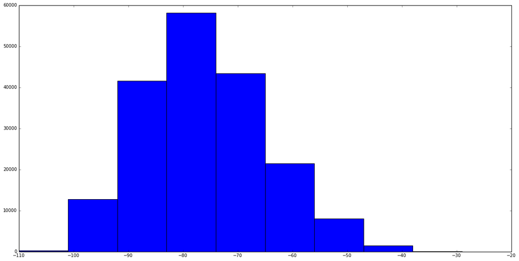

```python
plt.hist(bigdf["rssi"])
plt.show()
```

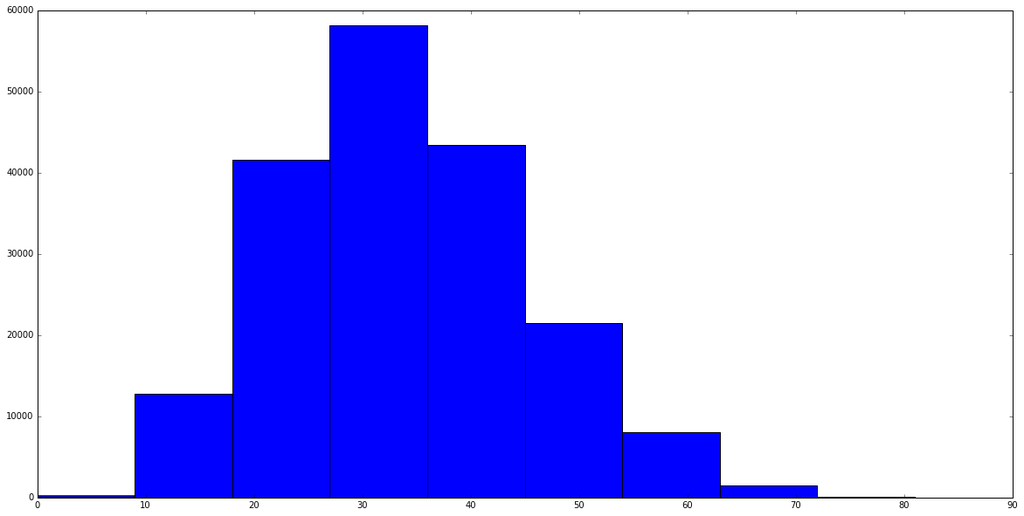

```python
# rescale rssi between 0 and max in positive numbers
# bigger number means more powerful signal
minPower = min(bigdf.rssi)
bigdf['rssiAdj'] = bigdf.rssi - minPower
plt.hist(bigdf["rssiAdj"])
plt.show()
```

This is all detections, for all people in the time window.

It's way too hectic to tell us much more than people don't go to the library much.

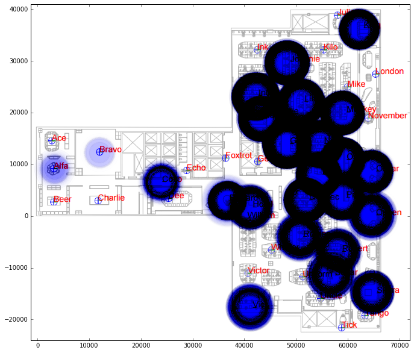

```python
img = imread("map.png")
plt.scatter(bigdf.x, bigdf.y, zorder=1, s=abs(bigdf.rssiAdj)*100, alpha=0.005)
plt.imshow(img, zorder=0, extent=[-1300, 72000, -24000, 41000])
#                                [left,  right, bottom, top  ]
plt.show()
```

So, let's subset the data and just look at one person. I don't know who person 297 is, they are the first in the dataset so *first in best dressed* (whatever that means).

```
Working with 1277 detections
```

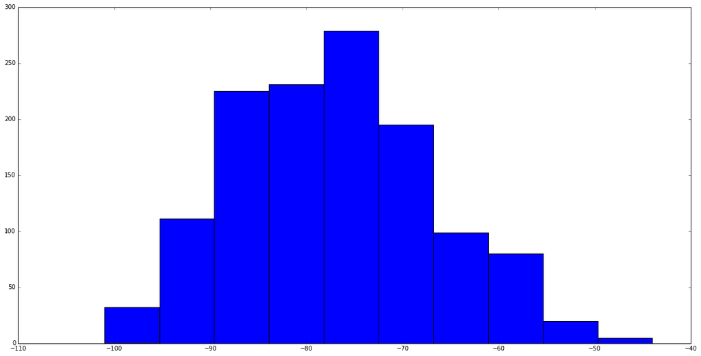

```python
person297df = bigdf[bigdf.minor == 297]
print "Working with",person297df.shape[0],"detections"
plt.hist(person297df.rssi)
plt.show()
```

```python
uniqueAgents = person297df.agentName.unique()
print "This person was picked up on these bases:",uniqueAgents
person297df.head()
```

```
This person was picked up on these bases: ['Sugar' 'India' 'Queen' 'Oscar' 'Harry' 'Pip' 'Sierra' 'Papa' 'Robert'
 'Lima' 'King' 'Vic' 'Nuts' 'Hotel' 'Orange' 'Quebec' 'Coco' 'Golf'
 'Johnnie' 'Edward' 'Monkey' 'Romeo']
```

|  | agentId | major | minor | rssi | tx | uuid | timestamp | agentName | location | x | y | rssiAdj |
| --- | --- | --- | --- | --- | --- | --- | --- | --- | --- | --- | --- | --- |
| 0 | 0000000081d28129 | 1 | 297 | -66 | -58 | 17520757a1412b175c03687a7102a104 | 2016-09-20 14:00:00.038 | Sugar | Principals Table (South) | 56755.95339 | -11320.44941 | 44 |
| 35 | 0000000081d28129 | 1 | 297 | -55 | -58 | 17520757a1412b175c03687a7102a104 | 2016-09-20 14:00:00.994 | Sugar | Principals Table (South) | 56755.95339 | -11320.44941 | 55 |
| 64 | 0000000081d28129 | 1 | 297 | -73 | -58 | 17520757a1412b175c03687a7102a104 | 2016-09-20 14:00:01.954 | Sugar | Principals Table (South) | 56755.95339 | -11320.44941 | 37 |
| 164 | 0000000081d28129 | 1 | 297 | -68 | -58 | 17520757a1412b175c03687a7102a104 | 2016-09-20 14:00:04.811 | Sugar | Principals Table (South) | 56755.95339 | -11320.44941 | 42 |
| 290 | 0000000081d28129 | 1 | 297 | -55 | -58 | 17520757a1412b175c03687a7102a104 | 2016-09-20 14:00:08.629 | Sugar | Principals Table (South) | 56755.95339 | -11320.44941 | 55 |

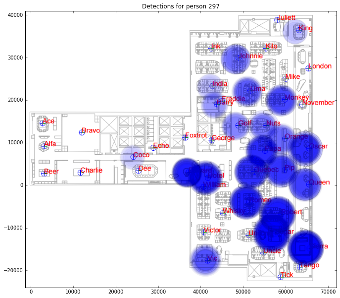

```
All detections in this time period. Circle radius shows signal strength.
2016-09-20 14:00:00.030000 First Recording in this set
2016-09-20 14:02:54.735000 Last Recording in this set
0 days 00:02:54.705000 Range covered
```

```
(Timestamp('2016-09-20 14:00:00.030000'),
 Timestamp('2016-09-20 14:02:54.735000'),
 Timedelta('0 days 00:02:54.705000'))
```

```python
plt.title('Detections for person 297')
img = imread("map.png")
plt.scatter(person297df.x, person297df.y, zorder=1, s=abs(person297df.rssiAdj)*100, alpha=0.02)
plt.imshow(img, zorder=0, extent=[-1300, 72000, -24000, 41000])
#                                [left,  right, bottom, top  ]
plt.show()
print "All detections in this time period. Circle radius shows signal strength."
timeStats(person297df)
```

This is all very well, but how do we tell what happened over time. This is 3 minutes of data. Were they moving or is there just a massive detection radius?

Lets try to animate things:

```python
#this takes quite a long time
def timeSliced(startTime, windowLength, df):
    if type(startTime) is str:
        startTime = dateutil.parser.parse(startTime)
    delta = datetime.timedelta(seconds=windowLength)
    endTime = startTime+delta
    df = df[(df.timestamp>startTime) &
            (df.timestamp<endTime)]
    centroid = {"x":df["x"].mean(), "y":df["y"].mean()}
    #print "start:",startTime," end:",endTime, " delta:",delta, df.shape#, "\n",df.timestamp

    plt.title('Detections for person 297 from '+str(startTime)+" to "+str(startTime+delta)) #TODO, make this a bit nicer
    img = imread("map.png")

    plt.scatter(df.x, df.y, zorder=1, s=abs(df.rssiAdj)*100, alpha=0.2)

    plt.scatter(centroid["x"], centroid["y"], c="r", zorder=2, s=100)

    plt.imshow(img, zorder=0, extent=[-1300, 72000, -24000, 41000])
    #                                [left,  right, bottom, top  ]
    # plt.show() #don't show, we need to save
    plt.savefig("anim/foo"+str(startTime)+".png", bbox_inches='tight')
    plt.clf()

ts=timeStats(person297df)
timeSize = ts[2]
stepSize = 0.5 #in seconds
steps = int(timeSize.total_seconds() / stepSize)
print "will make",steps,"frames"

for i in range(steps):
    s = ts[0]+datetime.timedelta(seconds=stepSize*i)
    timeSliced(s,
               stepSize,
               person297df)
#send a system command to make this into a gif. See https://community.linuxmint.com/tutorial/view/1118
os.system("convert -delay 20 -loop 0 anim/*.png result.gif")
```

```
2016-09-20 14:00:00.030000 First Recording in this set
2016-09-20 14:02:54.735000 Last Recording in this set
0 days 00:02:54.705000 Range covered
will make 349 frames
```

```
0
```

[figure not shown]

This image shows the detections from person 297.

They are broken into roughly 0.5 second windows.

The red dot is the unweighted centroid of the detections in that window.

It will be interesting to play around with weighting the centroid by detection strength.

```python
#makes centroids for each time window, This then gets shown on a static image.
def timeSlicedCentroids(startTime, windowLength, df):
    if type(startTime) is str:
        startTime = dateutil.parser.parse(startTime)
    delta = datetime.timedelta(seconds=windowLength)
    endTime = startTime+delta
    df = df[(df.timestamp>startTime) &
            (df.timestamp<endTime)]
    #print "start:",startTime," end:",endTime, " delta:",delta, df.shape#, "\n",df.timestamp
    return {"x":df["x"].mean(), "y":df["y"].mean()}

centroids = []
for i in range(steps):
    s = ts[0]+datetime.timedelta(seconds=stepSize*i)
    tsc = timeSlicedCentroids(s,
               stepSize,
               person297df)
    centroids.append(tsc)

centroidsdf = pd.DataFrame(centroids)
centroidsdf.dropna(inplace=True)
centroidsdf.head()
```

|  | x | y |
| --- | --- | --- |
| 0 | 57221.780112 | -4126.321498 |
| 1 | 53917.134128 | 5763.869497 |
| 3 | 56757.759377 | 1666.015647 |
| 7 | 61410.328340 | -10774.393707 |
| 9 | 55434.459742 | 2662.061848 |

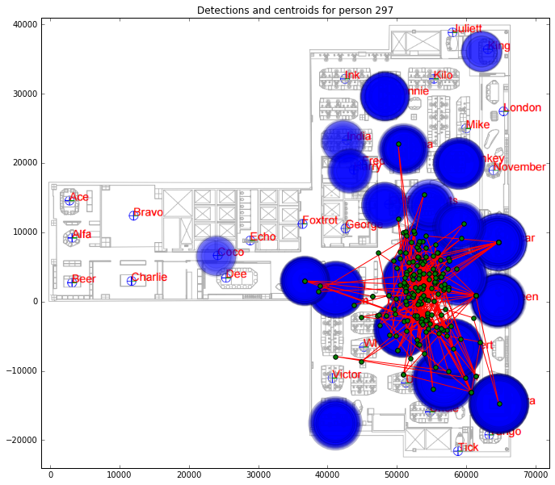

```
All detections in this time period. Circle radius shows signal strength.
Time window size: 0.5 seconds
2016-09-20 14:00:00.030000 First Recording in this set
2016-09-20 14:02:54.735000 Last Recording in this set
0 days 00:02:54.705000 Range covered
```

```
(Timestamp('2016-09-20 14:00:00.030000'),
 Timestamp('2016-09-20 14:02:54.735000'),
 Timedelta('0 days 00:02:54.705000'))
```

```python
plt.title('Detections and centroids for person 297')
img = imread("map.png")
plt.scatter(person297df.x, person297df.y, zorder=1, s=abs(person297df.rssiAdj)*100, alpha=0.1)
plt.plot(   centroidsdf.x, centroidsdf.y, c="r", zorder=2)
plt.scatter(centroidsdf.x, centroidsdf.y, c="g", zorder=3, s=30)
plt.imshow(img, zorder=0, extent=[-1300, 72000, -24000, 41000])
#                                [left,  right, bottom, top  ]
plt.show()
print "All detections in this time period. Circle radius shows signal strength."
print "Time window size:",stepSize,"seconds"
timeStats(person297df)
```

If we try a different approach, what does it look like from the point of view of the base station?

This graph shows the rssi for the bases that detected this person.

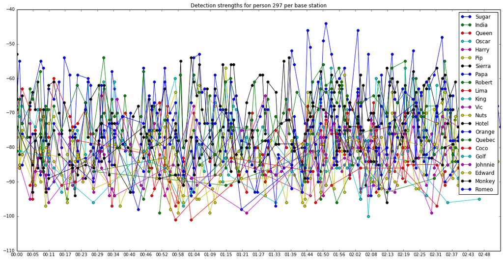

```python
basesToCareAbout = person297df.agentName.unique()

fig, ax = plt.subplots()
plt.title('Detection strengths for person 297 per base station')
legendStuff = []
for base in basesToCareAbout:
    localDF = person297df[person297df.agentName == base]
    plt.plot_date(localDF.timestamp, localDF.rssi, ls='solid')
    legendStuff.append(base)
plt.legend(legendStuff)
start, end = ax.get_xlim() #set these so that the individual plots don't bounce
bottom, top = ax.get_ylim()
step = (end-start)/30
ax.xaxis.set_ticks(np.arange(start, end, step))
dateFormat = matplotlib.dates.DateFormatter('%M:%S')
ax.xaxis.set_major_formatter(dateFormat)
plt.show()
```

I think that this is too dense to work with. Let's try animating it:

```python
basesToCareAbout = person297df.agentName.unique()

for base in basesToCareAbout:
    plt.title('Detection strengths for person 297 per base station')
    localDF = person297df[person297df.agentName == base]
    plt.plot_date(localDF.timestamp, localDF.rssi, ls='solid')
    plt.legend([base])
    plt.xlim([start, end])
    plt.ylim([bottom, top])
    plt.savefig("lineplt/lines"+base+".png", bbox_inches='tight')
    plt.clf()

#send a system command to make this into a gif. See https://community.linuxmint.com/tutorial/view/1118
os.system("convert -delay 20 -loop 0 lineplt/*.png linePlots.gif")
```

```
0
```

[figure not shown]